# Lab B1

STA 198 Summer 2020 (Jiang)

Bonus lab: Web scraping

This lab will introduce web scraping of HTML web pages using CSS selector gadgets in R. This will not be assigned for a grade, but is rather meant to serve as a resource for your data science career (and may be helpful on your final project!). The solutions for the exercises will be released on Wednesday, July 15.

# HTML

HTML stands for **h**yper**t**ext **m**arkup **l**anguage, and describes the structure of a web page. Your browser interprets this structure and contents and displays the results. The basic building blocks include elements, tags, and attributes: - an element is a component of an HTML document - elements contain tags (start and end tag) - attributes provide additional information about HTML elements

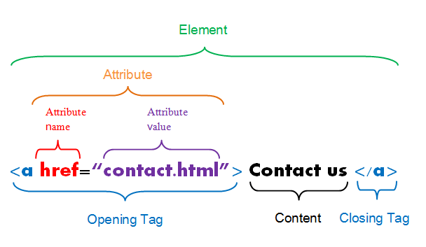

A simple HTML document may look like the following:

```html
<html>
<head>
<title>Web Scraping</title>
</head>
<body>

<h1>Using rvest</h1>
<p>To get started...</p>

</body>
</html>
```

We can visualize this in a tree-like structure.

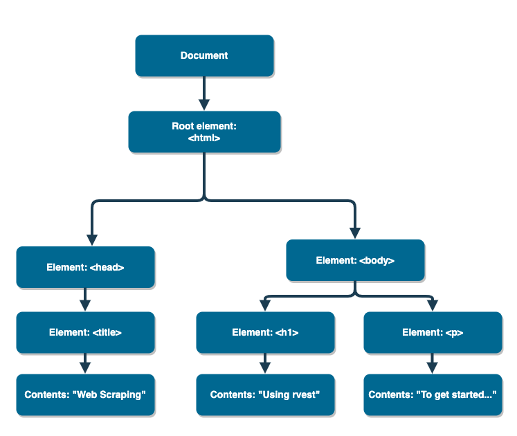

If we have access to an HTML document, we can use the `rvest` package by Hadley Wickham to extract information. It makes basic processing and manipulation of HTML documents easy.

```r
library(tidyverse)
library(rvest)
```

Some core functions are as follows:

| Function | Description |
| --- | --- |
| `xml2::read_html()` | read HTML from a character string or URL |
| `html_nodes()` | select specified pieces from the HTML document using CSS selectors |
| `html_table()` | parse an HTML table into a data frame |
| `html_text()` | extract content |
| `html_name()` | extract tag names |
| `html_attrs()` | extract all attributes and values |
| `html_attr()` | extract value for a specified attribute’s name |

# HTML in R

Let’s create a simple HTML document as a string to demonstrate some of these functions.

```r
simple_html <- "<html>
<head>
<title>Web Scraping</title>
</head>
<body>
<h1>Using rvest</h1>
<p>To get started...</p>
</body>
</html>"
```

First, let’s read it in:

```r
html_simple <- read_html(simple_html)
```

What does it look like?

```r
html_simple
```

```
## {html_document}
## <html>
## [1] <head>\n<meta http-equiv="Content-Type" content="text/html; charset=UTF-8 ...
## [2] <body>\n<h1>Using rvest</h1>\n<p>To get started...</p>\n</body>
```

Let’s now extract the component corresponding to `Using rvest`, and the actual text and name of the tag:

```r
h1_nodes <- html_nodes(html_simple, css = "h1")
h1_nodes
```

```
## {xml_nodeset (1)}
## [1] <h1>Using rvest</h1>
```

```r
h1_nodes %>%
  html_text()
```

```
## [1] "Using rvest"
```

```r
h1_nodes %>%
  html_name()
```

```
## [1] "h1"
```

# Scaling up

Most HTML documents are not as simple as what we just examined. There may be tables, hundreds of links, paragraphs of text, and more. Naturally, you might wonder: - How do we handle larger HTML documents? - How do we know what to provide to `css` in function `html_nodes()` when we attempt to subset the HTML document? - Are these functions in `rvest` vectorized? For instance, are we able to get all the content in the `td` tags on the slide that follows?

In Chrome, you can view the HTML document associated with a web page by going to `View > Developer > View Source`.

```html
<html lang=en>
<head>
   <title>Rays Notebook: Open Water Swims 2020 — The Whole Shebang</title>
</head>
<body>
<main class=schedule>
<h1>The Whole Shebang</h1>

<p>This schedule lists every swim in the database. 383 events.</p>

<table class=schedule>
<thead><tr><th>Date</th><th>Location</th><th>Name</th><th>Distance</th><th>More</th></tr></thead>
<tbody>

<tr id=January>
<td class=date>Jan 12, Sun</td>
<td class=where>
   <a class=mapq href="http://www.google.com/maps/?q=27.865501,-82.631997">Petersburg, FL</a>
   <span class=more>
   Gandy Beach, Gandy Blvd N St, Petersburg, FL
   </span>
</td>
<td class=name><a href="http://tampabayfrogman.com/">Tampa Bay Frogman</a></td>
<td class=distance>5 km</td>
<td class=more><span class=time>7:15 AM</span>, Old Tampa Bay.</td>
</tr>
</body>
</html>
```

This is a snippet from HTML document associated with the website [here](https://raysnotebook.info/ows/schedules/The%20Whole%20Shebang.html).

# CSS selectors

CSS stands for **c**ascading **s**tyle **s**heets, and describes how HTML elements are to be displayed on screen, paper, or in other media. CSS can be added to HTML elements in 3 ways: - Inline: by using the style attribute in HTML elements - Internal: by using a `<style>` element in the `<head>` section - External: by using an external CSS file

To extract components out of HTML documents use `html_nodes()` and CSS selectors. In CSS, selectors are patterns used to select elements you want to style. We can determine the necessary CSS selectors we need via the point-and-click tool [selector gadget](https://selectorgadget.com/). More on this in a moment.

Examples of CSS selectors are given below:

[output not shown]

For more CSS selector references click [here](https://www.w3schools.com/cssref/css_selectors.asp).

# SelectorGadget example

[SelectorGadget](https://selectorgadget.com/) makes identifying the CSS selector you need by easily clicking on items on a webpage. Check out the [video here](https://player.vimeo.com/video/52055686) for more details.

Let’s go to http://books.toscrape.com/catalogue/page-1.html and scrape the first page of data on books with regard to their title, price, and star rating. We’ll organize our results in a neatly formatted tibble similar to below.

```r
# A tibble: 20 x 3
   title                                             price rating
   <chr>                                             <chr> <chr>
 1 A Light in the Attic                              £51.… Three
 2 Tipping the Velvet                                £53.… One
 3 Soumission                                        £50.… One
 4 Sharp Objects                                     £47.… Four
 5 Sapiens: A Brief History of Humankind             £54.… Five
 6 The Requiem Red                                   £22.… One
 7 The Dirty Little Secrets of Getting Your Dream J… £33.… Four
 8 The Coming Woman: A Novel Based on the Life of t… £17.… Three
 9 The Boys in the Boat: Nine Americans and Their E… £22.… Four
10 The Black Maria                                   £52.… One
# … with 10 more rows
```

**The pre-recorded material will walk through this example in detail**.

# Overall workflow

The overall workflow for webscraping is as follows:

- Understand the website’s hierarchy and what information you need.
- Read and save the HTML document from the URL.

  ```r
  html_obj <- read_html("www.website-to-scrape.com")
  ```

- Use SelectorGadget to identify relevant CSS selectors.
- Subset the resulting html document using CSS selectors.

  ```r
  html_obj %>%
    html_nodes(css = "specified_css_selector")
  ```

- Further extract attributes, text, or tags by adding another layer with

  ```r
  html_obj %>%
    html_nodes(css = "specified_css_selector") %>%
    html_*()
  ```

  where `*` is `text`, `attr`, `attrs`, `name`, or `table`.

# Your turn!

Access the 250 top-rated movies according to their IMDb ratings, available here: https://www.imdb.com/chart/top.

Create a table which provides the titles, year, and IMDb scores for these movies. Your output should look similar to:

```
## # A tibble: 250 x 3
##    title                                             year   score
##    <chr>                                             <chr>  <dbl>
##  1 The Shawshank Redemption                          (1994)   9.2
##  2 The Godfather                                     (1972)   9.1
##  3 The Godfather: Part II                            (1974)   9
##  4 The Dark Knight                                   (2008)   9
##  5 12 Angry Men                                      (1957)   8.9
##  6 Schindler's List                                  (1993)   8.9
##  7 The Lord of the Rings: The Return of the King     (2003)   8.9
##  8 Pulp Fiction                                      (1994)   8.8
##  9 The Good, the Bad and the Ugly                    (1966)   8.8
## 10 The Lord of the Rings: The Fellowship of the Ring (2001)   8.8
## # ... with 240 more rows
```

# References

- Easily Harvest (Scrape) Web Pages. (2020). Rvest.tidyverse.org. Retrieved from https://rvest.tidyverse.org/
- W3Schools Online Web Tutorials. (2020). W3schools.com. Retrieved from https://www.w3schools.com/
- SelectorGadget: point and click CSS selectors. (2020). Selectorgadget.com. Retrieved from https://selectorgadget.com/